## Source Code for *In-person schooling and associated COVID-19 risk in the United States over Spring Semester 2021*

#### Kirsten E. Wiens, Claire P. Smith, Elena Badillo-Goicoechea, Kyra H. Grantz, M. Kate Grabowski, Andrew S. Azman, Elizabeth A. Stuart, Justin Lessler

Code is provided to reproduce the primary in-person schooling (`1-Main-Schooling-Analysis.Rmd`) and occupation/work outside home (`2-Educators-Analysis.Rmd`) analyses using a synthetic dataset. Hence, results produced when knitting these documents will **not** match those presented in the accompanying paper.

Data to reproduce paper figures/tables are freely available from the CMU Delphi Research Group to researchers at universities and non-profits as detailed at Getting Data Access - Delphi Epidata API (cmu-delphi.github.io).

Please reach out to justin[at]jhu.edu if you have any questions.

## Figure S7

Changes in paid work outside the home by occupation. Percent of all survey respondents in each occupation category that reported working outside of the home for pay in January and June, weighted to account for survey design. Respondents missing occupation designations are excluded. Occupations with fewer than 100,000 respondents are grouped in “Other”.

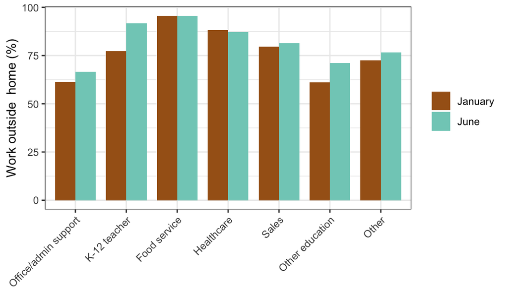

## Figure 9

Risk by occupation and paid work outside the home. Odds ratio of COVID-19-related outcomes, contrasting office workers not reporting extra-household work for pay to those in other employment categories not reporting work for pay outside the home (top row), and to those reporting work for pay outside the home (bottom row). The middle row shows the odds ratio (i.e., increased risk) within each category associated with working outside the home compared to no work outside the home. Food service workers are excluded from this analysis because less than 5% reported working exclusively from home (Fig. S7). Results are shown across the study period from Jan. 12 to Jun. 12.

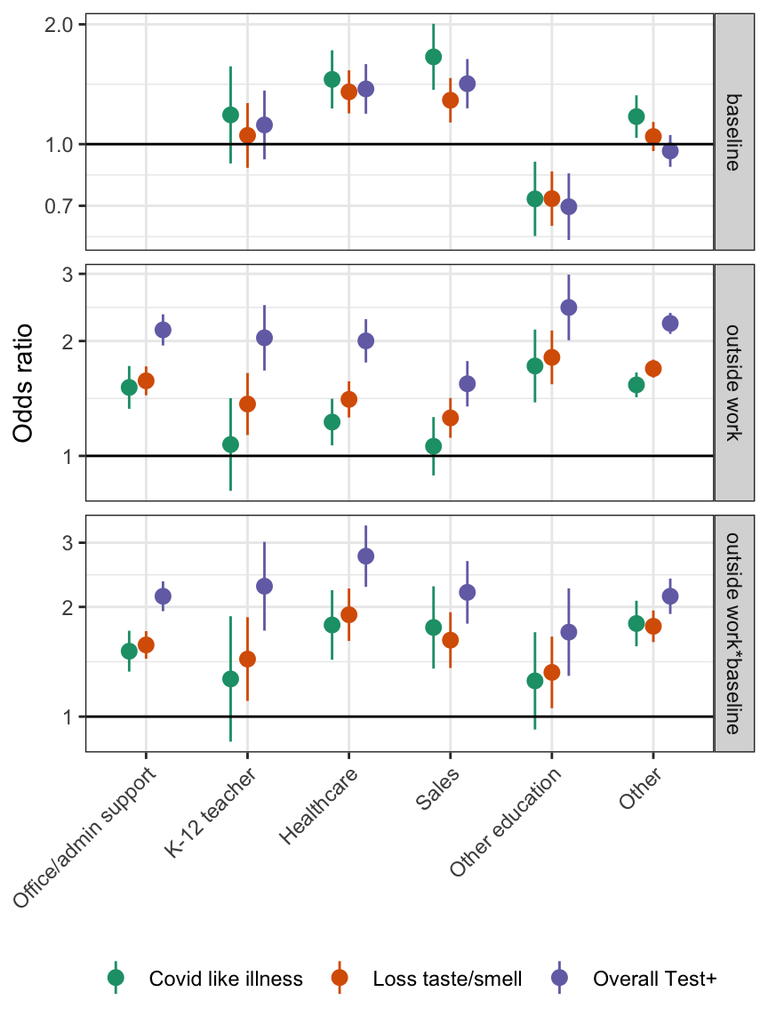

## Figure S8

Risk by occupation and paid work outside the home. Odds ratio of COVID-19-related outcomes, contrasting office workers not reporting extra-household work for pay to those in other employment categories not reporting work for pay outside the home (top row), and to those reporting work for pay outside the home (bottom row). The middle row shows the odds ratio (i.e., increased risk) within each category associated with working outside the home compared to no work outside the home. Food service workers are excluded from this analysis because less than 5% reported working exclusively from home (Fig. S7). Results are shown stratified by time periods Jan. 12 to Feb. 28 (Jan-Feb), Mar. 1 to Apr. 30 (Mar-Apr), and May 1 to Jun. 12 (May-Jun)).

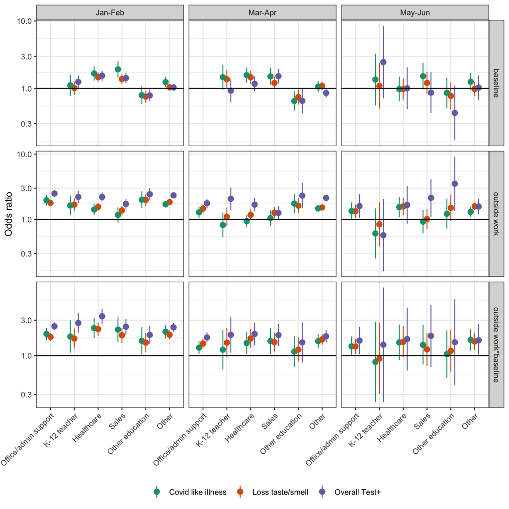

## Figure S9

COVID-19 risk among K-12 Teachers by vaccination status and paid work outside the home. Odds ratio of COVID-19-related outcomes, contrasting unvaccinated K-12 Teachers not reporting extra-household work for pay to vaccinated (any doses) K-12 teachers not reporting work for pay outside the home (top), and to those reporting work for pay outside the home (bottom). The middle row shows the odds ratio (i.e., increased risk) within each vaccination category associated with working outside the home compared to no work outside the home.

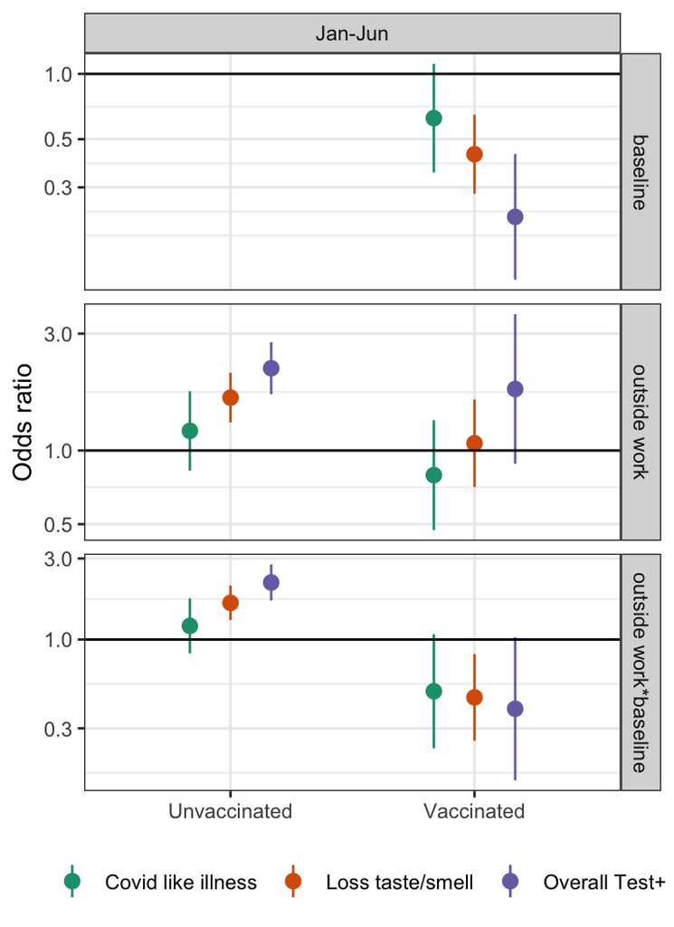

## Table S8

Relative odds of COVID-19-related outcomes among respondents who did, and did not, report any paid work outside the home during different time periods compared to office and administrative staff not working outside of the home for pay.

| Occupation | Loss of taste/smell adj. OR | Loss of taste/smell 95% CI | COVID like illness adj OR | COVID like illness 95% CI | Test+ adj OR | Test+ 95% CI |
| --- | --- | --- | --- | --- | --- | --- |
| January to June |  |  |  |  |  |  |
| Healthcare | 1.35 | 1.19–1.53 | 1.45 | 1.23–1.72 | 1.38 | 1.19–1.59 |
| K12Teacher | 1.05 | 0.87–1.27 | 1.18 | 0.89–1.57 | 1.12 | 0.92–1.36 |
| Other | 1.05 | 0.96–1.14 | 1.17 | 1.04–1.33 | 0.96 | 0.88–1.05 |
| OtherEductation | 0.73 | 0.62–0.85 | 0.73 | 0.59–0.90 | 0.70 | 0.57–0.84 |
| Sales | 1.29 | 1.13–1.47 | 1.66 | 1.37–2.01 | 1.42 | 1.23–1.64 |
| Office and admin support * NA | 1.57 | 1.44–1.72 | 1.51 | 1.33–1.72 | 2.14 | 1.95–2.35 |
| Healthcare * NA | 1.41 | 1.26–1.57 | 1.23 | 1.07–1.41 | 2.00 | 1.76–2.28 |
| K12Teacher * NA | 1.37 | 1.13–1.65 | 1.07 | 0.81–1.42 | 2.04 | 1.67–2.48 |
| Other * NA | 1.69 | 1.60–1.79 | 1.54 | 1.42–1.65 | 2.22 | 2.09–2.37 |
| OtherEductation * NA | 1.81 | 1.54–2.13 | 1.72 | 1.38–2.14 | 2.45 | 2.01–2.99 |
| Sales * NA | 1.26 | 1.12–1.42 | 1.06 | 0.89–1.26 | 1.55 | 1.35–1.77 |
| January to February |  |  |  |  |  |  |
| Healthcare | 1.47 | 1.25–1.72 | 1.67 | 1.31–2.12 | 1.54 | 1.30–1.84 |
| K12Teacher | 1.01 | 0.81–1.26 | 1.11 | 0.78–1.59 | 1.25 | 1.00–1.56 |
| Other | 1.04 | 0.93–1.17 | 1.24 | 1.03–1.48 | 1.03 | 0.92–1.16 |
| OtherEductation | 0.75 | 0.61–0.93 | 0.79 | 0.59–1.07 | 0.79 | 0.64–0.96 |
| Sales | 1.38 | 1.16–1.63 | 1.92 | 1.44–2.56 | 1.43 | 1.19–1.70 |
| Office and admin support * NA | 1.78 | 1.58–2.00 | 1.96 | 1.63–2.37 | 2.49 | 2.21–2.80 |
| Healthcare * NA | 1.55 | 1.35–1.78 | 1.41 | 1.15–1.73 | 2.20 | 1.88–2.57 |
| K12Teacher * NA | 1.68 | 1.35–2.09 | 1.63 | 1.15–2.31 | 2.21 | 1.78–2.73 |
| Other * NA | 1.84 | 1.71–1.98 | 1.70 | 1.52–1.90 | 2.33 | 2.15–2.52 |
| OtherEductation * NA | 1.99 | 1.60–2.46 | 2.00 | 1.48–2.70 | 2.43 | 1.97–2.98 |
| Sales * NA | 1.37 | 1.17–1.61 | 1.17 | 0.89–1.53 | 1.72 | 1.45–2.04 |
| March to April |  |  |  |  |  |  |
| Healthcare | 1.46 | 1.18–1.81 | 1.57 | 1.21–2.04 | 1.17 | 0.90–1.51 |
| K12Teacher | 1.37 | 0.99–1.89 | 1.47 | 0.95–2.26 | 0.92 | 0.63–1.37 |
| Other | 1.09 | 0.95–1.25 | 1.07 | 0.88–1.28 | 0.86 | 0.73–1.00 |
| OtherEductation | 0.74 | 0.58–0.96 | 0.65 | 0.47–0.90 | 0.65 | 0.42–1.01 |
| Sales | 1.20 | 0.98–1.48 | 1.51 | 1.12–2.02 | 1.52 | 1.18–1.94 |
| Office and admin support * NA | 1.46 | 1.26–1.69 | 1.28 | 1.05–1.57 | 1.76 | 1.50–2.07 |
| Healthcare * NA | 1.17 | 0.96–1.42 | 0.94 | 0.75–1.17 | 1.68 | 1.32–2.14 |
| K12Teacher * NA | 1.09 | 0.79–1.51 | 0.82 | 0.53–1.26 | 2.06 | 1.39–3.07 |
| Other * NA | 1.52 | 1.39–1.66 | 1.47 | 1.31–1.64 | 2.13 | 1.90–2.39 |
| OtherEductation * NA | 1.62 | 1.24–2.11 | 1.74 | 1.24–2.46 | 2.31 | 1.47–3.61 |
| Sales * NA | 1.26 | 1.04–1.53 | 1.05 | 0.79–1.38 | 1.25 | 0.98–1.59 |
| May to June |  |  |  |  |  |  |
| Healthcare | 0.97 | 0.68–1.40 | 0.98 | 0.64–1.49 | 1.00 | 0.49–2.06 |
| K12Teacher | 1.09 | 0.50–2.36 | 1.35 | 0.56–3.26 | 2.45 | 0.71–8.50 |
| Other | 0.98 | 0.78–1.24 | 1.25 | 0.93–1.69 | 1.03 | 0.67–1.56 |
| OtherEductation | 0.77 | 0.49–1.23 | 0.86 | 0.51–1.45 | 0.43 | 0.17–1.10 |
| Sales | 1.20 | 0.82–1.76 | 1.52 | 0.96–2.39 | 0.87 | 0.43–1.75 |
| Office and admin support * NA | 1.33 | 1.05–1.68 | 1.34 | 0.98–1.82 | 1.59 | 1.05–2.42 |
| Healthcare * NA | 1.57 | 1.15–2.15 | 1.54 | 1.08–2.19 | 1.66 | 0.86–3.23 |
| K12Teacher * NA | 0.84 | 0.38–1.83 | 0.61 | 0.25–1.47 | 0.57 | 0.16–2.04 |
| Other * NA | 1.58 | 1.38–1.81 | 1.30 | 1.10–1.54 | 1.57 | 1.19–2.07 |
| OtherEductation * NA | 1.50 | 0.94–2.39 | 1.22 | 0.72–2.05 | 3.51 | 1.35–9.13 |
| Sales * NA | 1.01 | 0.71–1.43 | 0.92 | 0.61–1.39 | 2.13 | 1.10–4.14 |

## Table S9

Relative odds of COVID-19-related outcomes among K-12 teachers who were vaccinated with any number of COVID-19 vaccine doses and who did, or did not, report any paid work outside the home during different time periods compared to K-12 teachers who were unvaccinated and not working outside of the home for pay.

| Vaccine status | Loss of taste/smell adj. OR | Loss of taste/smell 95% CI | COVID like illness adj OR | COVID like illness 95% CI | Test+ adj OR | Test+ 95% CI |
| --- | --- | --- | --- | --- | --- | --- |
| January to June |  |  |  |  |  |  |
| vaccinated | 0.43 | 0.28–0.65 | 0.63 | 0.35–1.11 | 0.22 | 0.11–0.43 |
| unvaccinated * NA | 1.64 | 1.30–2.08 | 1.20 | 0.83–1.75 | 2.17 | 1.70–2.77 |
| vaccinated * NA | 1.07 | 0.71–1.61 | 0.79 | 0.47–1.33 | 1.78 | 0.88–3.60 |
| January to February |  |  |  |  |  |  |
| vaccinated | 0.17 | 0.06–0.43 | 0.20 | 0.07–0.61 | 0.24 | 0.11–0.53 |
| unvaccinated * NA | 1.63 | 1.25–2.13 | 1.37 | 0.91–2.06 | 2.18 | 1.66–2.85 |
| vaccinated * NA | 2.32 | 0.87–6.22 | 3.09 | 1.03–9.28 | 2.29 | 1.00–5.25 |
| March to April |  |  |  |  |  |  |
| vaccinated | 0.31 | 0.17–0.59 | 0.36 | 0.16–0.84 | 0.10 | 0.04–0.25 |
| unvaccinated * NA | 1.45 | 0.84–2.52 | 0.82 | 0.38–1.77 | 2.73 | 1.42–5.25 |
| vaccinated * NA | 1.04 | 0.68–1.59 | 0.84 | 0.49–1.44 | 3.44 | 1.55–7.62 |
| May to June |  |  |  |  |  |  |
| vaccinated | 0.67 | 0.13–3.46 | 1.08 | 0.14–8.32 | 0.08 | 0.01–1.12 |
| unvaccinated * NA | 1.65 | 0.43–6.31 | 1.68 | 0.29–9.81 | 0.31 | 0.08–1.25 |
| vaccinated * NA | 0.77 | 0.28–2.10 | 0.46 | 0.15–1.40 | 0.48 | 0.04–6.02 |